# Exercise #3

Fortgeschrittene Statistische Software für NF

Chanyoung Woo (12368781)  
2024-06-07

## General Remarks

- You can submit your solutions in teams of up to 3 students.
- Include all your team-member’s names and student numbers (Martrikelnummern) in the `authors` field.
- Please use the exercise template document to work on and submit your results.
- Use a level 2 heading for each new exercise and answer each subtask next to it’s bullet point or use a new level 3 heading if you want.
- Always render the R code for your solutions and make sure to include the resulting data in your rendered document.
  - Make sure to not print more than 10 rows of data (unless specifically instructed to).
- Always submit both the rendered document(s) as well as your source Rmarkdown document. Submit the files separately on moodle, **not** as a zip archive.

## Exercise 1: Initializing git (4 Points)

For this whole exercise sheet we will be tracking all our changes to it in git.

1. Start by initializing a new R project with git support, called `2024-exeRcise-sheet-3`. If you forgot how to do this, you can follow this [guide](https://malikaihle.github.io/Introduction-RStudio-Git-GitHub/rstudio_project.html).

-done

2. Commit the files generated by Rstudio.

-done

3. For all of the following tasks in this exercise sheet we ask you to always commit your changes after finishing each subtask e.g. create a commit after task *1d*, *1e* etc.

> Note: This applies only to answers that have text or code as their answer. If you complete tasks in a different order or forget to commit one, this is no problem. If you change your answers you can just create multiple commits to track the changes.

-done

4. Name 2 strengths and 2 weaknesses of git. (Don’t forget to create a commit after this answer, see *1c*)

**2 strengths of Git:** - Every git user has access to all the versions of the ongoing git-project. This enables offline work and efficient version management. - Also one of the greatest strength of git is Branching and Merging. This allows users to work on multiple development paths and merging it afterwards. You don’t have to wait for someone to finish working so you can work on the project. You can just create different branches and merge it afterwards.

**2 weaknesses of Git:** - The extensive set of Git-commands are very complex and difficult for beginners. So for beginners there are many things to learn before even to get started with git. - Also for beginners problems/conflicts can be difficult to solve. Especially Merging conflicts in large projects can be very challenging to resolve.

5. Knit this exercise sheet. Some new files will automatically be generated when knitting the sheet e.g. the HTML page. Ignore these files, as we only want to track the source files themselves.

## Exercise 2: Putting your Repository on GitHub (3.5 Points)

For this task you will upload your solution to GitHub.

1. Create a new repository on GitHub in your account named `exeRcise-sheet-3`. Make sure you create a **public repository** so we are able to see it for grading. Add the link to the repository below:

https://github.com/Reiskorn03/exeRcise-sheet-3

2. Push your code to this new repository by copying and executing the snippet on github listed under `…or push an existing repository from the command line`.

-done

3. Regularly push your latest changes to GitHub again and especially do so when you are finished with this sheet.

-done

## Exercise 3: Baby-Names in Munich (3.5 Points)

Download the latest open datasets on given names (“Vornamen”) from the open data repository of the city of Munich for the years `2023` and `2022`.

Link: https://opendata.muenchen.de/dataset/vornamen-von-neugeborenen

1. Download the data for both years and track it in git. For small datasets like these adding them to git is not a problem.

-done

2. Load the data for both years into R. Check the type of the count variable (“Anzahl”) and look into the data to determine why it is not numeric? Fix the problem in an appropriate manner, it is OK if some of the counts are inaccurate because of this. Explain your solution and the repercussions.

```r
library(dplyr)
data_2023 <- read.csv("vornamen-muenchen-2023.csv")
data_2022 <- read.csv("open_data_portal_2022.csv")

str(data_2023)
```

```
'data.frame':   4289 obs. of  3 variables:
 $ Vorname   : chr  "Leon" "Maximilian" "Emilia" "Paul" ...
 $ Anzahl    : chr  "107" "105" "89" "89" ...
 $ Geschlecht: chr  "m" "m" "w" "m" ...
```

```r
str(data_2022)
```

```
'data.frame':   4390 obs. of  3 variables:
 $ Vorname   : chr  "Emilia" "Emma" "Mia" "Sophia" ...
 $ Anzahl    : chr  "103" "101" "93" "78" ...
 $ Geschlecht: chr  "w" "w" "w" "w" ...
```

```r
summary(data_2023)
```

```
   Vorname             Anzahl           Geschlecht
 Length:4289        Length:4289        Length:4289
 Class :character   Class :character   Class :character
 Mode  :character   Mode  :character   Mode  :character
```

```r
summary(data_2022)
```

```
   Vorname             Anzahl           Geschlecht
 Length:4390        Length:4390        Length:4390
 Class :character   Class :character   Class :character
 Mode  :character   Mode  :character   Mode  :character
```

```r
class(data_2023$Anzahl)
```

```
[1] "character"
```

```r
class(data_2022$Anzahl)
```

```
[1] "character"
```

```r
data_2023$Anzahl <- gsub("4 oder weniger", "2", data_2023$Anzahl)
data_2022$Anzahl <- gsub("4 oder weniger", "2", data_2022$Anzahl)

data_2023$Anzahl <- as.numeric(gsub("[^0-9]", "", data_2023$Anzahl))
data_2022$Anzahl <- as.numeric(gsub("[^0-9]", "", data_2022$Anzahl))

summary(data_2023$Anzahl)
```

```
   Min. 1st Qu.  Median    Mean 3rd Qu.    Max.
  2.000   2.000   2.000   3.906   2.000 107.000
```

```r
summary(data_2022$Anzahl)
```

```
   Min. 1st Qu.  Median    Mean 3rd Qu.    Max.
  2.000   2.000   2.000   3.997   2.000 104.000
```

Why are some of the values in **“Anzahl”** not numeric? **Answer:** As in further inspection of the two .csv files, if the count variable “Anzahl” is less than or equals to 4, it automatically defines its value to “4 oder weniger” which is translated to “smaller or equals 4”. So this is the reason why non-numeric values are defined as values of the count variables. **Solution:** To fix this issue of non-numeric values in the count variable, I changed all non-numeric values to 2, because 2 is the median of [0, 1, 2, 3, 4]. This may lead to a over/underestimation of the count variable that are actually more/less than 2. Also this data set may be distorted because now there are many values that equals 2, but it does not matter because the data set was inaccurate in the first place.

3. Calculate the total number of babies born in Munich in 2022 and 2023. Which year had the bigger baby-boom?

```r
total_babies_2022 <- sum(data_2022$Anzahl)
total_babies_2023 <- sum(data_2023$Anzahl)

cat("Total number of babies born in 2022:", total_babies_2022, "\n")
```

```
Total number of babies born in 2022: 17549
```

```r
cat("Total number of babies born in 2023:", total_babies_2023, "\n")
```

```
Total number of babies born in 2023: 16753
```

```r
if (total_babies_2023 > total_babies_2022) {
  cat("2023 had the bigger baby-boom.\n")
} else if (total_babies_2023 < total_babies_2022) {
  cat("2022 had the bigger baby-boom.\n")
} else {
  cat("Both years had the same number of babies born.\n")
}
```

```
2022 had the bigger baby-boom.
```

4. Add a new column `year` to both datasets which holds the correct year for each.

```r
data_2022$year <- 2022
data_2023$year <- 2023

head(data_2022)
```

```
  Vorname Anzahl Geschlecht year
1  Emilia    103          w 2022
2    Emma    101          w 2022
3     Mia     93          w 2022
4  Sophia     78          w 2022
5    Anna     72          w 2022
6     Lea     71          w 2022
```

```r
head(data_2023)
```

```
     Vorname Anzahl Geschlecht year
1       Leon    107          m 2023
2 Maximilian    105          m 2023
3     Emilia     89          w 2023
4       Paul     89          m 2023
5       Noah     83          m 2023
6      Anton     80          m 2023
```

5. Combine both datasets into one using `bind_rows()`.

```r
combined_data <- bind_rows(data_2022, data_2023)

str(combined_data)
```

```
'data.frame':   8679 obs. of  4 variables:
 $ Vorname   : chr  "Emilia" "Emma" "Mia" "Sophia" ...
 $ Anzahl    : num  103 101 93 78 72 71 71 67 65 61 ...
 $ Geschlecht: chr  "w" "w" "w" "w" ...
 $ year      : num  2022 2022 2022 2022 2022 ...
```

```r
summary(combined_data)
```

```
   Vorname              Anzahl         Geschlecht
 Length:8679        Min.   :  2.000   Length:8679
 Class :character   1st Qu.:  2.000   Class :character
 Mode  :character   Median :  2.000   Mode  :character
                    Mean   :  3.952
                    3rd Qu.:  2.000
                    Max.   :107.000
      year
 Min.   :2022
 1st Qu.:2022
 Median :2022
 Mean   :2022
 3rd Qu.:2023
 Max.   :2023
```

6. Combine the counts for same names to determine the most popular names across both years. Print out the top 10 names in a nicely formatted table for both years. Include a table caption.

```r
name_counts <- combined_data %>%
  group_by(Vorname, Geschlecht) %>%
  summarise(Total = sum(Anzahl, na.rm = TRUE)) %>%
  arrange(desc(Total))

top_10_names <- head(name_counts, 10)

knitr::kable(
  top_10_names,
  caption = "Top 10 Most Popular Baby Names in Munich (2022 and 2023)")
```

Table 1: Top 10 Most Popular Baby Names in Munich (2022 and 2023)

| Vorname | Geschlecht | Total |
| --- | --- | --- |
| Maximilian | m | 209 |
| Emilia | w | 192 |
| Leon | m | 188 |
| Anton | m | 181 |
| Emma | w | 172 |
| Felix | m | 166 |
| Mia | w | 163 |
| Paul | m | 161 |
| Noah | m | 159 |
| Jonas | m | 158 |

## Exercise 4: Open Analysis (4 points)

This exercise is a bit more open-ended. You can choose any dataset from [Our World in Data](https://ourworldindata.org/) and analyze it, while determining the research question yourself.

1. Go to https://github.com/owid/owid-datasets/tree/master/datasets and choose a dataset that interests you. You can have a look at https://ourworldindata.org/ to gather some inspiration.

Smoking prevalence and cigarette consumption (IHME, GHDx (2012)).csv

2. Download the dataset and track it in git.

-done

**Question:** Which 3 countries have the highest cigarette consumption per smoker per day in 2010? **Explanation:** It is really interesting which of the countries have the highest cigarette consumption per smoker per day because with this information you can possibly track how many cigarettes the country is consuming with the amount of smokers in their country.

5. Use R to answer your chosen question.

```r
library(dplyr)
library(ggplot2)
library(readr)

cigarette_data <-
  read_csv(
    "Smoking prevalence and cigarette consumption (IHME, GHDx (2012)).csv",
           show_col_types = FALSE)

data_2010 <- cigarette_data %>%
  filter(Year == 2010)

data_2010 <- data_2010 %>%
  dplyr::select(
    Entity,
    Year,
    `Cigarette consumption per smoker per day (IHME, GHDx (2012))`)

colnames(data_2010)[3] <- "Cigarettes_per_day"

top_3_countries <- data_2010 %>%
  arrange(desc(Cigarettes_per_day)) %>%
  head(3)

knitr::kable(
  top_3_countries,
  caption = "Top 3 Countries with Highest
  Cigarette Consumption per Smoker per Day in 2010")
```

Table 2: Top 3 Countries with Highest Cigarette Consumption per Smoker per Day in 2010

| Entity | Year | Cigarettes_per_day |
| --- | --- | --- |
| Suriname | 2010 | 109.8 |
| Saint Vincent and the Grenadines | 2010 | 82.9 |
| Brunei | 2010 | 48.2 |

6. Create a meaningful plot / figure with the dataset. Make sure to provide a figure caption (via the chunk options / Rmarkdown) and correctly label the figure.

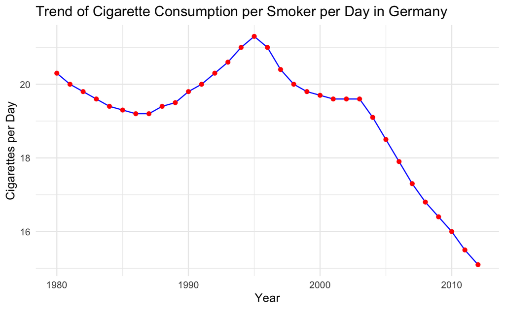

```r
library(dplyr)
library(ggplot2)
library(readr)

cigarette_data <-
  read_csv("Smoking prevalence and cigarette consumption (IHME, GHDx (2012)).csv",
           show_col_types = FALSE)

germany_data <- cigarette_data %>%
  filter(Entity == "Germany") %>%
  dplyr::select(Year, `Cigarette consumption per smoker per day (IHME, GHDx (2012))`)

colnames(germany_data)[2] <- "Cigarettes_per_day"

ggplot(germany_data, aes(x = Year, y = Cigarettes_per_day)) +
  geom_line(color = "blue") +
  geom_point(color = "red") +
  labs(title = "Trend of Cigarette Consumption per Smoker per Day in Germany",
       x = "Year",
       y = "Cigarettes per Day") +
  theme_minimal()
```

## Final Note

Make sure to push all your commits and changes to GitHub before submittining the exercise sheet.